# final project

## Ministry of Magic Classifications

- beast: classified as a beast but wasn’t classified based on how harmful they are
- x beast: harmless to humans
- xx beast: harmless and could be domesticated
- xxx beast: should be no trouble to competent wizards
- xxxx beast: dangerous and require special knowledge, only trained wizards should handle them, endangered or just too difficult to capture, rather than being dangerous
- xxxxx beast: are known wizard killers, are impossible to train or domesticate
- being: any creature that has sufficient intelligence to understand the laws of the magical community and to bear part of the responsibility in shaping those laws
- spirit: any creature that has a spectral body, is unaffected by gravity and is not actually alive
- non-being: are not born and can not be killed

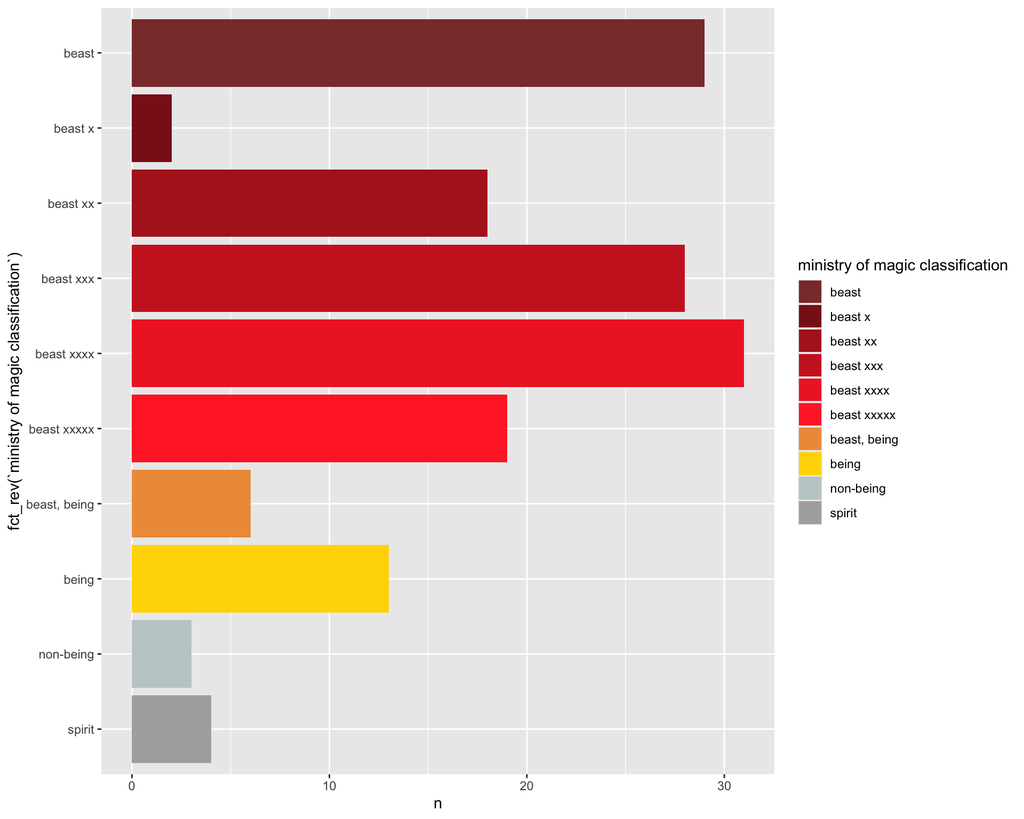

[output not shown]

# Movies

return = (future value - initial value) / initial value